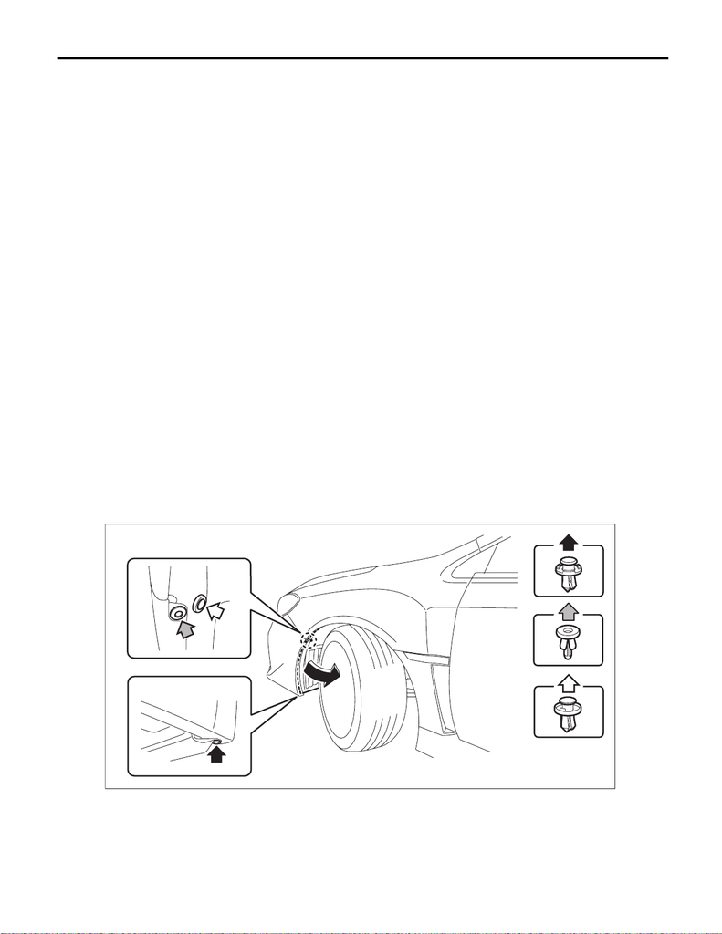

Headlight Bulb

LIGHTING SYSTEM

15.Headlight Bulb

A: REMOVAL

1. HIGH BEAM

CAUTION:

• Do not perform work with wet hands, because there is a possibility of electrical shock.

1) Disconnect the ground cable from battery. <Ref. to NT-5, BATTERY, NOTE, Note.>

NOTE:

For models other than STI model, disconnect the ground terminal from battery sensor.

2) Remove the clips and remove the air intake duct. (When removing the high beam bulb RH)

• Except for STI model: <Ref. to IN(w/o STI)-22, REMOVAL, Air Intake Duct.>

• STI model: <Ref. to IN(STI)-11, REMOVAL, Air Intake Duct.>

2. LOW BEAM

CAUTION:

• Do not perform work with wet hands, because there is a possibility of electrical shock.

NOTE:

Since the LED type is a non-disassembled part, it cannot be removed.

1) Disconnect the ground cable from battery. <Ref. to NT-5, BATTERY, NOTE, Note.>

NOTE:

For models other than STI model, disconnect the ground terminal from battery sensor.

[figure not shown]

Headlight Bulb

LIGHTING SYSTEM

B: INSTALLATION

1. HIGH BEAM

1) Install the high beam bulb. <Ref. to LI-26, HIGH BEAM BULB, ASSEMBLY, Headlight Assembly.>

2) Install the air intake duct. (When the high beam bulb RH was removed)

3) Connect the battery ground terminal. <Ref. to NT-5, BATTERY, NOTE, Note.>

NOTE:

For models other than STI model, connect the ground terminal to battery sensor.

2. LOW BEAM

1) Install the low beam bulb. <Ref. to LI-26, LOW BEAM BULB, ASSEMBLY, Headlight Assembly.>

2) Install the mud guard - front.

3) Connect the battery ground terminal. <Ref. to NT-5, BATTERY, NOTE, Note.>

NOTE:

For models other than STI model, connect the ground terminal to battery sensor.